# Using ggplot2 to Analyze Lake Mendota

Aditya Mehrotra

2023-11-07

## Overview

– The following document will analyze Lake Mendota freeze/thaw data set using ggplot2

## Lake Mendota

- Scientists have been recording the dates when Lake Mendota first closes with ice (at least half the surface is covered with ice) and opens (more than half the surface is liquid water) since the middle of the 1800s.
- In most winters, there is a single uninterrupted period of time from the first time the lake is closed in the winter to the first time it reopens in the spring.
  - Some winters have multiple intervals of closure
- The data set I am using summarizes the raw data with a single row for each winter from 1855–56 through last winter, 2021–22.
  - The variable `year1` is the first year of the given winter.
  - The variable `duration` is the total number of days that Lake Mendota was closed by ice in the given winter. (Note: the word “winter” used here specifies a single season spanning two consecutive calendar years and does not use the endpoints from the winter solstice to the spring equinox, for example.)

```r
mendota = read_csv("../../data/lake-mendota-winters-2022.csv")
mendota
```

```
## # A tibble: 167 × 7
##    winter  year1 intervals duration first_freeze last_thaw  decade
##    <chr>   <dbl>     <dbl>    <dbl> <date>       <date>      <dbl>
##  1 1855-56  1855         1      118 1855-12-18   1856-04-14   1850
##  2 1856-57  1856         1      151 1856-12-06   1857-05-06   1850
##  3 1857-58  1857         1      121 1857-11-25   1858-03-26   1850
##  4 1858-59  1858         1       96 1858-12-08   1859-03-14   1850
##  5 1859-60  1859         1      110 1859-12-07   1860-03-26   1850
##  6 1860-61  1860         1      117 1860-12-14   1861-04-10   1860
##  7 1861-62  1861         1      132 1861-12-02   1862-04-13   1860
##  8 1862-63  1862         1      104 1862-12-26   1863-04-09   1860
##  9 1863-64  1863         1      125 1863-12-18   1864-04-21   1860
## 10 1864-65  1864         1      118 1864-12-08   1865-04-05   1860
## # ℹ 157 more rows
```

### Question: How long does Lake Mendota freeze each winter?

#### Using a Scatter Plot with a Trend Line

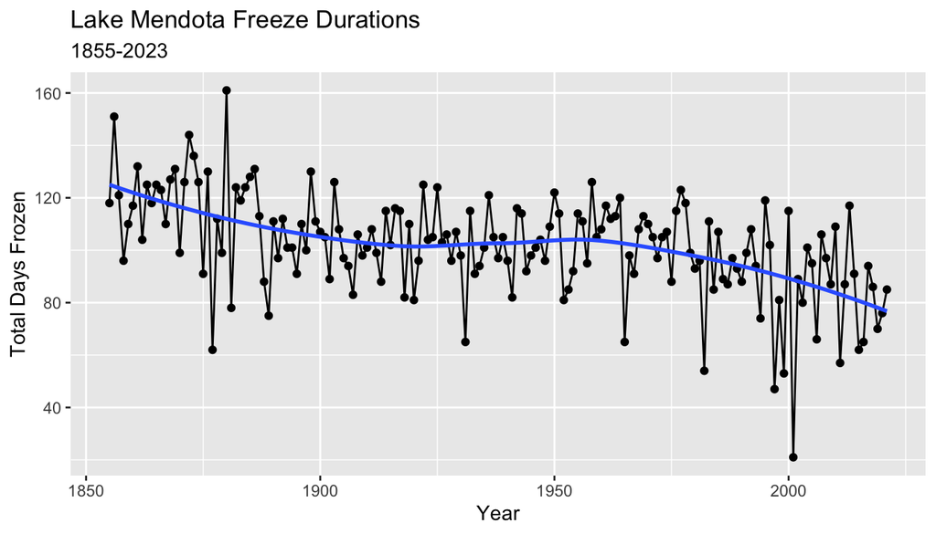

```r
freeze_duration = ggplot(mendota, aes(x=year1, y=duration)) +
  geom_point() +
  geom_line() +
  geom_smooth(se=FALSE) +
  xlab("Year") +
  ylab("Total Days Frozen") +
  ggtitle("Lake Mendota Freeze Durations", "1855-2023")
freeze_duration
```

##### Observations

- There appears to be a decrease in Lake Mendota’s freeze duration over time
- Informally, we can interpret the blue curve in the plot as a description of what the climate is doing in Wisconsin.
  - When ignoring the year-to-year fluctuations, we see that the average freeze duration of Lake Mendota over the winter has decreased from 120 days (around 17 weeks) in the mid 1850s to just under 80 days (around 11 weeks) in 2022.
- The variation of the points around the blue curve may be interpreted as random “noise” caused by differences in the weather at key parts of the fall and winter seasons.